# Chapter 6: Further Inference in Multiple Regression

## Recall: the multiple regression model

$$SALES=\beta_1+\beta_2PRICE+\beta_3ADVERT+e$$

- Estimating a regression is not the end of the analysis.
- **How do we know/test whether a coefficient matters?**

Remark:

Good econometrics is about asking good questions, not memorizing more formulas.

## A familiar test: the t-test

$$SALES=\beta_1+\beta_2PRICE+\beta_3ADVERT+e$$

Suppose we ask only: **Does the advertising matter?**

$$H_0:\;\beta_3=0$$

A **t-test** helps answer this *one-coefficient* question.

## A familiar test: the t-test

Suppose the test gives:

$$p=0.02$$

**Question:** Should we reject $H_0$ at the **5% significance level**?

**Answer:** Yes, since;
$$0.02<0.05$$

**Decision:** Reject the null hypothesis.

The advertising coefficient is statistically significant.

## When is a t-test not enough?

Suppose our model includes two advertising terms:

$$\begin{aligned}
SALES={}&\beta_1+\beta_2PRICE\\
&+\beta_3ADVERT+\beta_4ADVERT^2+e
\end{aligned}$$

We want to know whether **advertising matters as a group**.

## The question becomes a joint test

**Null hypothesis:** Neither advertising term matters.

$$H_0:\ \beta_3=0\ \text{and}\ \beta_4=0$$

**Alternative:** At least one is not zero.

Testing several restrictions together calls for an **F-test**.

## Remember the difference

**t-test:** Tests one coefficient.

**F-test:** Can test several coefficients **together**.

## Question:

If we test $\beta_3=0$ and $\beta_4=0$ simultaneously, which test should we use?

## Two models, one question

### Unrestricted model:

$$SALES = \beta_1 + \beta_2 PRICE + \beta_3 ADVERT + \beta_4 ADVERT^2 + e$$

Let us assume that advertising has **no** effect (i.e., $H_0: \beta_3=0,\beta_4=0$ is true)

### Restricted model:

$$SALES = \beta_1 + \beta_2 PRICE + e$$

## Compare the two models

We ask:

**Does adding the advertising terms improve the model enough?**

- Small improvement → weak evidence against $H_0$.
- Large improvement → stronger evidence against $H_0$.

The **F-test** measures this improvement relative to unexplained variation.

## What is SSE?

**SSE** = Sum of Squared Errors.

It measures how far observed values are from fitted values.

**Lower SSE means a better fit in the sample.**

But adding variables usually lowers SSE, even if they are not useful.

## How the F-test works

$$\boxed{F = \frac{(SSE_R-SSE_U)/J}{SSE_U/(N-K)}}$$

- $SSE_R$: from the **restricted** model
- $SSE_U$: from the **unrestricted** model
- $J$: number of restrictions; $N$: sample size
- $K$: number of parameters in the unrestricted model, **including the intercept**

**Interpretation:** Large $F$ means the restrictions substantially worsen the fit.

## How the F-test works

- Under the classical regression assumptions and $H_0$,
  $$F\sim F_c(1-\alpha,J,N-K)$$
- Compare the $F$-value to a critical value $F_c$.
- Reject the $H_0$ if $F \geq F_c$, keep otherwise

## The $F-$ distribution

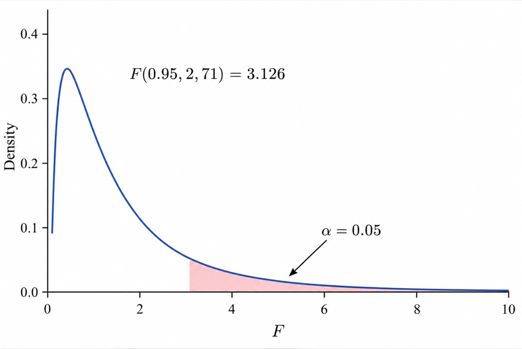

## Now It’s Your Turn!

Estimate the model in R, and answer the questions that follows.

$$SALES_i = \beta_1 + \beta_2 PRICE_i
+ \beta_3 ADVERT_i + \beta_4 ADVERT_i^2 + e_i$$

1. State the $H_0$ and $H_1$to test whether advertising expenditure has a joint effect on sales.
2. Conduct an F-test in R to test the hypotheses in question 1. Report the F-statistic and p-value.
3. At the 5% significance level, what is your conclusion?

## What the F-test does—and does not—say

**It tells us:** At least one advertising coefficient is different from zero.

**It does not tell us:**

- Which of the two advertising terms matters individually.

## Testing the significance of the model

Consider a general regression model:
$$y=\beta_1+\beta_2x_2+\cdots+\beta_Kx_K+e$$

To examine whether we have a viable explanatory model, we test

$$\begin{aligned}
H_0 &: \beta_2 =0, \beta_3 =0, \cdots = \beta_K = 0 \\[12pt]
H_1 &: \text{At least one } \beta_k \neq 0,
\quad k = 2, 3, \ldots, K
\end{aligned}$$

- The null hypothesis is a **joint** one because it has $K-1$ components.
- This is the **overall significance** test.

## Testing the significance of the model

$$y = \beta_1 + e, \ \ \ \ \ \ \space \text{(the restricted model)}$$

- The $F-$test statistic can be modified and written as:
  $$\boxed{F = \frac{(SST-SSE)/K-1}{SSE/(N-K)}}$$
- The calculated F-value can be compared with
  $$F_c=F_c(1-\alpha, K-1,N-K)$$
- Reject the $H_0$ if $F \geq F_c$, keep otherwise

## Your Turn!

Estimate the model in R, and answer the questions that follows.

$$SALES = \beta_1 + \beta_2 PRICE
+ \beta_3 ADVERT_i + \beta_4 ADVERT^2 + e$$

1. State the $H_0$ and $H_1$ for testing the overall significance of the regression model.
2. Using the regression output in R, report the F-statistic and its corresponding p-value.
3. At the 5% significance level, is the regression model statistically significant? Explain your conclusion.

## When to use $t$ versus $F$

| Question | Typical test |
| --- | --- |
| Is **one** coefficient zero? | $t$-test |
| Are **several** coefficients jointly zero? | $F$-test |
| Is the **entire regression** significant? | Overall $F$-test |
| Does a **linear combination** equal a value? | $F$-test / Wald test |

## When are $t$ and $F-$ tests equivalent

$$SALES = \beta_1 + \beta_2 PRICE
+ \beta_3 ADVERT_i + \beta_4 ADVERT^2 + e$$

Suppose now we want to test:
$$\begin{aligned}
H_0 &: \beta_2 =0 , \ \ \ \
H_1: \beta_2 \neq 0
\end{aligned}$$

**Question:** Can we use an $F-$ test or $t-$ test?

**Check:**

Using the previous example that $H_0: \beta_2=0 \text H_1: \beta \neq 0$

## When are $t$ and $F-$ tests equivalent

- Two-tail $t-$ tests are equivalent to $F-$ tests when there is a single hypothesis in $H_0$.
- An $F-$ test cannot be used as an alternative to a one-tail $t-$ test.
- For a **single equality restriction**, in the classical linear regression setup:$\boxed{F=t^2}$

## F-test: what should you remember?

1. Write the **joint null hypothesis**.
2. Obtain the **F-statistic or p-value**.
3. Compare the p-value with the significance level.
4. State the conclusion **in words**.

Always interpret the decision in terms of the economic question.

## Check your understanding

Suppose given a wage model:
$$Wage = \beta_1+\beta_2 educ + \beta_3 exper + \beta_4 exper^2+e$$

**Question:** Do the *two experience terms together* improve the wage model?

1. Write the null hypothesis.
2. Would you use $t$ or $F$?
3. If $p=0.03$, what is your conclusion at 5%?

**Answer:** $H_0:\beta_3=\beta_4=0$.

Use an F-test. Reject at 5%; the two terms are jointly significant.

## 2. Can economic theory help estimation?

Sometimes we know more than what is contained in our sample.

**Example: Demand theory** suggests that increasing all prices and income by the *same percentage* should leave real demand unchanged.

$$ln(q)=\beta_1 +\beta_2ln(pb)+\beta_3ln(pl)+\beta_4 ln(pr)+\beta_5ln(I)+e$$

$$\beta_2+\beta_3+\beta_4+\beta_5=0$$

We can impose this relationship as a **restriction** when estimating.

## 2. Can economic theory help estimation?

- Substituting the restriction gives:

$$ln(q)=\beta_1 +\beta_2ln(\frac{pb}{pr})+\beta_3ln(\frac{pl}{pr})+\beta_5ln(\frac{I}{pr})+e$$

Restrictions add information, but a wrong restriction can bias results.

## Your Turn!

- Estimate the restricted model above using the **beer** data from the text book.
- What is the price elasticity of demand for beer, liquor,remaining goods and services, and income?

## 3: Choosing a regression model

Two questions come first:

**Are we explaining a causal effect?**

or

**Are we trying to predict an outcome?**

The answer affects which variables we should include.

## 3. Choosing a regression model

### Causality

**Question:** What happens to wages *because of* one more year of education?

We need credible assumptions and appropriate control variables.

### Prediction

**Question:** What wage do we expect for a person with these characteristics?

We care primarily about performance on new observations.

**A variable can be useful for prediction without having a causal effect.**

## What if we omit an important variable?

Suppose we study the relationship between **education and wages**.

But we leave out **ability**.

If ability affects wages **and** is related to education, the education coefficient may be biased.

This is **omitted variable bias**.

## Omitted-variable bias

Suppose the true model is:

$$y=\beta_1+\beta_2x+\beta_3z+e$$

But we estimate $y$ using only $x$.

Bias is a concern when:

1. $z$ actually affects $y$ ($\beta_3\neq0$), **and**
2. $z$ is correlated with $x$.

$$\operatorname{Bias}(\widehat\beta_2)\ \approx\ \beta_3\frac{\operatorname{Cov}(x,z)}{\operatorname{Var}(x)}$$

## Irrelevant variables: the other mistake

A variable with no true effect may add little useful information.

It can make our coefficient estimates **less precise**.

**Lesson:** Neither “include everything” nor “include only significant variables” is a reliable modeling rule.

## How to assess specification

Ask the simple questions:

1. Does the specification or functional form make **economic sense**?
2. Have we omitted an important variable?
3. Do residual plots suggest a **missed pattern**?
4. Are conclusions robust to **reasonable alternatives**?

**RESET** is one additional test for possible misspecification.

## 6.4: Prediction

A regression can be used to predict an outcome.

For example, predict the **sales** of a store for a given price and advertising expenditure.

A prediction is not guaranteed to equal the actual outcome.

Predictions contain uncertainty.

## How do we compare prediction models?

A model should predict **new observations**, not only fit past data.

We can reserve some observations as a **test sample**.

Then compare predicted and actual values.

**Smaller prediction errors are better.**

## Which model predicts better?

Compare candidate models with evidence beyond in-sample $R^2$.

| Measure | What to look for |
| --- | --- |
| Adjusted $R^2$ | Higher (in-sample, penalizes complexity) |
| AIC / BIC (SC) | Lower among comparable models |
| Holdout RMSE | **Lower on data not used for fitting** |

$$RMSE=\sqrt{\frac1m\sum_{i=1}^{m}(y_i-\widehat y_i)^2}$$

**Teaching priority:** Holdout performance is often the most persuasive evidence of predictive ability.

## 6.5: What is collinearity?

Two explanatory variables may move closely together.

For example, **advertising on TV** and **advertising online** may increase at the same time.

Then it is difficult to identify their **separate effects**.

## Why does collinearity matter?

Strong collinearity can produce:

- Large standard errors.
- Small t-statistics.
- Unstable coefficient estimates.

An insignificant t-test does not always mean a variable is unimportant.

## What should you remember from Chapter 6?

| Question | Main tool / idea |
| --- | --- |
| Do variables matter together? | Joint **F-test** |
| Can theory help? | **Restricted** least squares |
| Did we choose the right variables? | **Specification**, controls, RESET |
| Will our forecasts generalize? | **Prediction intervals**, holdout RMSE |
| Why are standard errors large? | **Collinearity**, VIF |
| Parameters enter nonlinearly? | **Nonlinear least squares** |

## Check your understanding

**1.** A test of $\beta_2=0$ only: t-test or F-test?

**2.** A test of $\beta_2=\beta_3=0$: t-test or F-test?

**3.** If the p-value is $0.03$, what do we decide at 5%?

**4.** Why might two related explanatory variables cause large standard errors?

## Answers

**1.** t-test (an F-test is also possible for one restriction).

**2.** F-test.

**3.** Reject the null hypothesis.

**4.** The data do not clearly separate the variables’ individual effects.

## For independent reading

*Principles of Econometrics*, 5th ed., Chapter 6.

Prioritize Sections **6.1, 6.3, 6.4 and 6.5**.

Sections **6.2 and 6.6** are introduced briefly here; refer to the textbook for more detail.